# **Loan Default Prediction**

## **Problem Definition**

### **The Context:**

- Why is this problem important to solve?

This loan default prediction problem is important because it helps banks minimize financial losses from defaulted loans, improving their profitability and stability. It enables more accurate, consistent, and unbiased assessments of creditworthiness, reducing human error and bias in decision-making. By automating the process, banks can operate more efficiently, lower costs, and improve customer experience by offering more tailored loan products. Additionally, it helps ensure compliance with regulatory requirements and reduces the risk of penalties or audits. Overall, it leads to more responsible and fair lending practices.

### **The objective:**

- What is the intended goal?

The intended goal of this project is to build a classification model that accurately predicts which clients are likely to default on their loans. The model should help banks make more informed, efficient, and unbiased loan approval decisions while providing insights into the key factors that influence loan repayment.

### **The key questions:**

- What are the key questions that need to be answered?
1. Which features (such as loan amount, job type, or credit history) are most predictive of loan default?
2. How can we handle missing data and ensure the dataset is clean for modeling?
3. Which machine learning model (or combination of models) provides the best balance of accuracy and interpretability?
4. How do we avoid biases in the model that may have been present in the original loan approval process?
5. What evaluation metrics should we use to assess model performance, especially in terms of minimizing false negatives (defaults)?
6. How can the model's predictions be explained and justified to ensure transparency and trust in the decision-making process?

### **The problem formulation**:

- What is it that we are trying to solve using data science?
- We are trying to solve the problem of accurately predicting which loan applicants are likely to default on their loans. Using data science, the goal is to create a model that can assess creditworthiness based on historical data, improving the loan approval process by making it more efficient, consistent, and unbiased. This model should help banks reduce financial losses, mitigate risk, and make more informed, data-driven lending decisions.

## **Data Description:**

The Home Equity dataset (HMEQ) contains baseline and loan performance information for 5,960 recent home equity loans. The target (BAD) is a binary variable that indicates whether an applicant has ultimately defaulted or has been severely delinquent. This adverse outcome occurred in 1,189 cases (20 percent). 12 input variables were registered for each applicant.

- **BAD:** 1 = Client defaulted on loan, 0 = loan repaid
- **LOAN:** Amount of loan approved.
- **MORTDUE:** Amount due on the existing mortgage.
- **VALUE:** Current value of the property.
- **REASON:** Reason for the loan request. (HomeImp = home improvement, DebtCon= debt consolidation which means taking out a new loan to pay off other liabilities and consumer debts)
- **JOB:** The type of job that loan applicant has such as manager, self, etc.
- **YOJ:** Years at present job.
- **DEROG:** Number of major derogatory reports (which indicates a serious delinquency or late payments).
- **DELINQ:** Number of delinquent credit lines (a line of credit becomes delinquent when a borrower does not make the minimum required payments 30 to 60 days past the day on which the payments were due).
- **CLAGE:** Age of the oldest credit line in months.
- **NINQ:** Number of recent credit inquiries.
- **CLNO:** Number of existing credit lines.
- **DEBTINC:** Debt-to-income ratio (all your monthly debt payments divided by your gross monthly income. This number is one way lenders measure your ability to manage the monthly payments to repay the money you plan to borrow.

## **Import the necessary libraries and Data**

```python
import pandas as pd
import matplotlib.pyplot as plt
import seaborn as sns
from scipy.stats import ttest_ind, chi2_contingency
import numpy as np
from scipy.stats import zscore
from sklearn.model_selection import train_test_split, GridSearchCV
from sklearn.linear_model import LogisticRegression
from sklearn.metrics import accuracy_score, classification_report, confusion_matrix
from sklearn.preprocessing import OneHotEncoder
from sklearn.compose import ColumnTransformer
from sklearn.pipeline import Pipeline
from sklearn.impute import SimpleImputer
from sklearn.linear_model import LogisticRegressionCV
from sklearn.tree import DecisionTreeClassifier
from sklearn.ensemble import HistGradientBoostingClassifier
from sklearn.ensemble import RandomForestClassifier
```

## **Data Overview**

- Reading the dataset
- Understanding the shape of the dataset
- Checking the data types
- Checking for missing values
- Checking for duplicated values

```python
# Load the dataset
file_path = 'hmeq.csv'
df = pd.read_csv(file_path)

# Understanding the shape of the dataset, checking data types, missing values, and duplicated values
dataset_info = {
    "shape": df.shape,
    "data_types": df.dtypes,
    "missing_values": df.isnull().sum(),
    "duplicated_values": df.duplicated().sum()
}

dataset_info
```

```
{'shape': (5960, 13),
 'data_types': BAD          int64
 LOAN         int64
 MORTDUE    float64
 VALUE      float64
 REASON      object
 JOB         object
 YOJ        float64
 DEROG      float64
 DELINQ     float64
 CLAGE      float64
 NINQ       float64
 CLNO       float64
 DEBTINC    float64
 dtype: object,
 'missing_values': BAD           0
 LOAN          0
 MORTDUE     518
 VALUE       112
 REASON      252
 JOB         279
 YOJ         515
 DEROG       708
 DELINQ      580
 CLAGE       308
 NINQ        510
 CLNO        222
 DEBTINC    1267
 dtype: int64,
 'duplicated_values': 0}
```

## Summary Statistics

```python
# Generate summary statistics for the numerical columns in the dataset
summary_stats = df.describe()
print(summary_stats)

# Unique values in categorical columns
unique_values = df.select_dtypes(include=['object']).nunique()

# Mode (most frequent) values for categorical columns
mode_values = df.select_dtypes(include=['object']).mode().iloc[0]

# Value counts for categorical columns
value_counts = df.select_dtypes(include=['object']).apply(pd.Series.value_counts)

# For standard deviation, skewness, and kurtosis, we only need numeric columns (doing it normally gave me a future warning)
numeric_cols = df.select_dtypes(include=['number'])

# Standard deviation
std_devs = numeric_cols.std()

# Skewness
skewness = numeric_cols.skew()

# Kurtosis
kurtosis = numeric_cols.kurt()

# Collecting all the results into a dictionary
summary_stats_extended = {
    "Unique Values": unique_values,
    "Standard Deviations": std_devs,
    "Value Counts (Categorical)": value_counts,
    "Skewness": skewness,
    "Kurtosis": kurtosis
}

# Display the results
print("\nUnique Values:\n", unique_values)
print("\nStandard Deviations:\n", std_devs)
print("\nValue Counts (Categorical):\n", value_counts)
print("\nSkewness:\n", skewness)
print("\nKurtosis:\n", kurtosis)

# I noticed a lot of missing values, and wanted to know if the value was missing meant it was more indicative of loan default, so I did this:

# Calculate the overall loan default rate (BAD = 1) for all entries in the dataset, for comparison
overall_bad_rate = df['BAD'].mean()
overall_bad_rate
print(f"\nOverall loan default rate: {overall_bad_rate}\n")

# Function to compare loan default rate for missing vs non-missing values for each column, excluding 'BAD' and 'LOAN'
def compare_default_rate_without_bad_loan(df):
    comparison_results = {}

    # Iterate through all columns in the dataset, excluding 'BAD' and 'LOAN'
    for column in df.columns:
        if column not in ['BAD', 'LOAN']:
            # Calculate the loan default rate (BAD = 1) where data is missing vs where it's not
            bad_rate_missing = df[df[column].isnull()]['BAD'].mean()
            bad_rate_not_missing = df[df[column].notnull()]['BAD'].mean()

            comparison_results[column] = {
                "Bad Rate (Missing)": bad_rate_missing,
                "Bad Rate (Not Missing)": bad_rate_not_missing
            }

    return comparison_results

# Run the comparison
default_comparison_without_bad_loan = compare_default_rate_without_bad_loan(df)

# Print the results
for column, rates in default_comparison_without_bad_loan.items():
    print(f"{column} - Missing Values: {rates['Bad Rate (Missing)']}, Not Missing Values: {rates['Bad Rate (Not Missing)']}")
```

```
               BAD          LOAN        MORTDUE          VALUE          YOJ  \
count  5960.000000   5960.000000    5442.000000    5848.000000  5445.000000
mean      0.199497  18607.969799   73760.817200  101776.048741     8.922268
std       0.399656  11207.480417   44457.609458   57385.775334     7.573982
min       0.000000   1100.000000    2063.000000    8000.000000     0.000000
25%       0.000000  11100.000000   46276.000000   66075.500000     3.000000
50%       0.000000  16300.000000   65019.000000   89235.500000     7.000000
75%       0.000000  23300.000000   91488.000000  119824.250000    13.000000
max       1.000000  89900.000000  399550.000000  855909.000000    41.000000

             DEROG       DELINQ        CLAGE         NINQ         CLNO  \
count  5252.000000  5380.000000  5652.000000  5450.000000  5738.000000
mean      0.254570     0.449442   179.766275     1.186055    21.296096
std       0.846047     1.127266    85.810092     1.728675    10.138933
min       0.000000     0.000000     0.000000     0.000000     0.000000
25%       0.000000     0.000000   115.116702     0.000000    15.000000
50%       0.000000     0.000000   173.466667     1.000000    20.000000
75%       0.000000     0.000000   231.562278     2.000000    26.000000
max      10.000000    15.000000  1168.233561    17.000000    71.000000

           DEBTINC
count  4693.000000
mean     33.779915
std       8.601746
min       0.524499
25%      29.140031
50%      34.818262
75%      39.003141
max     203.312149

Unique Values:
 REASON    2
JOB       6
dtype: int64

Standard Deviations:
 BAD            0.399656
LOAN       11207.480417
MORTDUE    44457.609458
VALUE      57385.775334
```

[output cut: 46 more lines]

```
dtype: float64

Overall loan default rate: 0.199496644295302

MORTDUE - Missing Values: 0.20463320463320464, Not Missing Values: 0.1990077177508269
VALUE - Missing Values: 0.9375, Not Missing Values: 0.1853625170998632
REASON - Missing Values: 0.19047619047619047, Not Missing Values: 0.19989488437281008
JOB - Missing Values: 0.08243727598566308, Not Missing Values: 0.20524555535997183
YOJ - Missing Values: 0.1262135922330097, Not Missing Values: 0.2064279155188246
DEROG - Missing Values: 0.1228813559322034, Not Missing Values: 0.20982482863670981
DELINQ - Missing Values: 0.12413793103448276, Not Missing Values: 0.20762081784386618
CLAGE - Missing Values: 0.2532467532467532, Not Missing Values: 0.19656758669497523
NINQ - Missing Values: 0.14705882352941177, Not Missing Values: 0.20440366972477064
CLNO - Missing Values: 0.23873873873873874, Not Missing Values: 0.1979783896828163
DEBTINC - Missing Values: 0.6203630623520127, Not Missing Values: 0.08587257617728532
```

- Observations from Summary Statistics
- A lot of this data is very sensitive to change, so any editing of the missing values must be handled with care, especially the DEROG and DELINQ. I can't remove them, though, because I don't know why they're missing. I could if I knew it was just random chance (ie a computer issue), but not if somehow they were intentionally left out. Any model I make must be thorough and careful!
- Missing values from categorical data doesn't seem to impact loan default in any way that would worry me, just the opposite for missing the job value, even. However, the missing data for the numerical values value and debt-to-income are extremely alarming. The default rates are very high. It's almost 100% for value! I think when I make a model for this, I will add a specific value to indicate the missing variables, to train the data that it's important to consider for loan defaults. I'm not sure yet how to approach that because they're numerical, but I definitely think it's necessary. For the others, it seems unnecessary.
- I might be missing something, but there doesn't seem to be anything else that stands out.

## **Exploratory Data Analysis (EDA) and Visualization**

- EDA is an important part of any project involving data.
- It is important to investigate and understand the data better before building a model with it.
- A few questions have been mentioned below which will help you approach the analysis in the right manner and generate insights from the data.
- A thorough analysis of the data, in addition to the questions mentioned below, should be done.

**Leading Questions**:

1. What is the range of values for the loan amount variable "LOAN"?
2. How does the distribution of years at present job "YOJ" vary across the dataset?
3. How many unique categories are there in the REASON variable?
4. What is the most common category in the JOB variable?
5. Is there a relationship between the REASON variable and the proportion of applicants who defaulted on their loan?
6. Do applicants who default have a significantly different loan amount compared to those who repay their loan?
7. Is there a correlation between the value of the property and the loan default rate?
8. Do applicants who default have a significantly different mortgage amount compared to those who repay their loan?

### **Univariate Analysis**

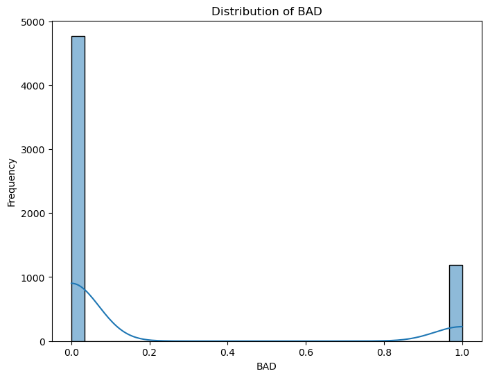

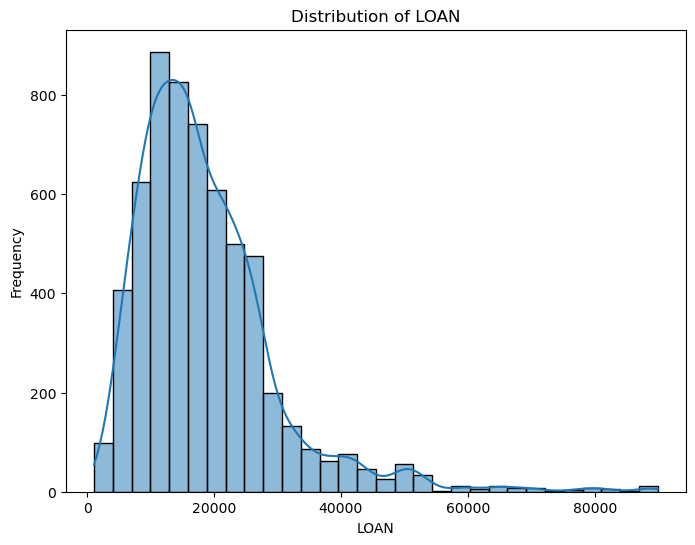

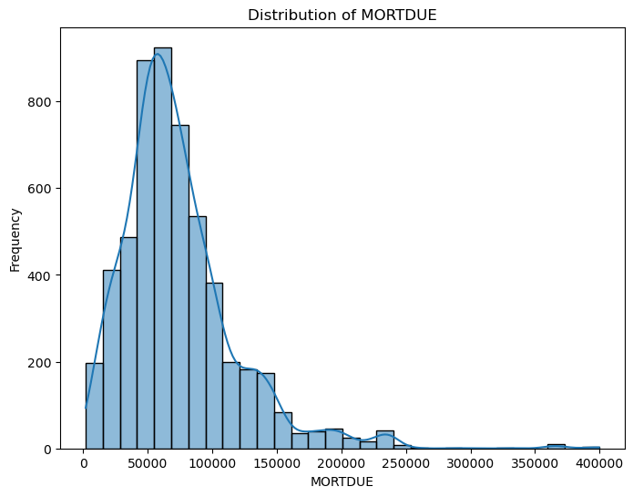

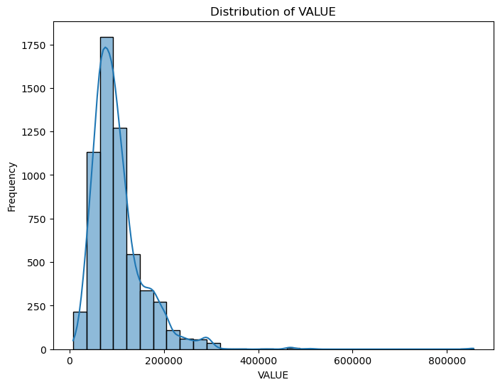

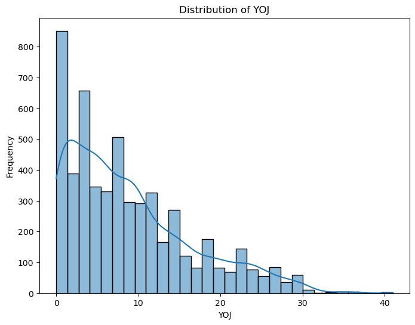

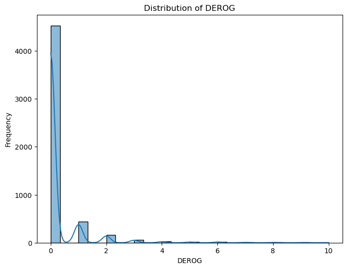

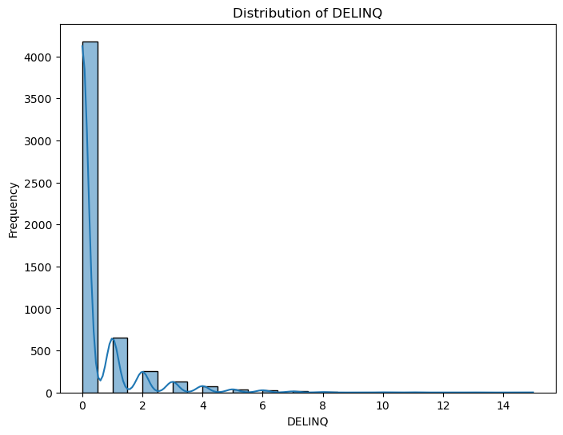

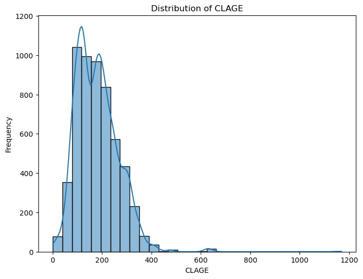

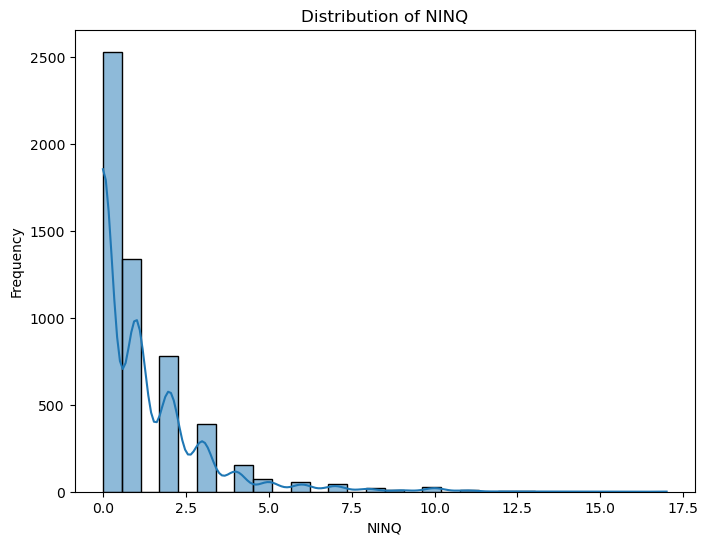

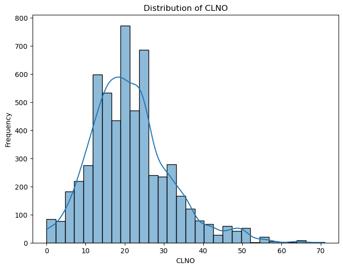

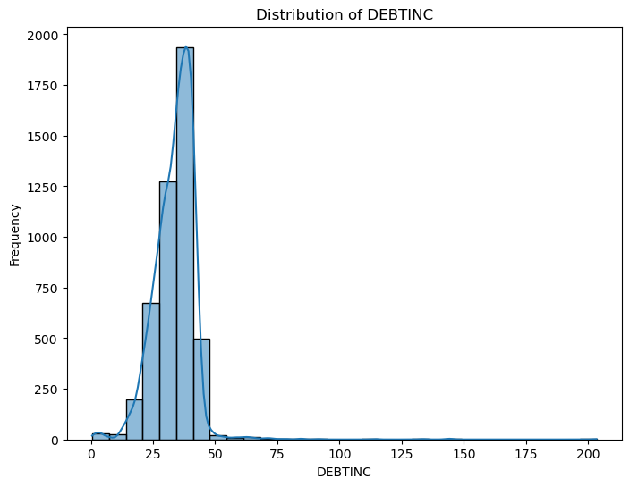

```python
# I wasn't sure what would be most useful for univariate analysis, but I went with a histogram just to visualize anything I may have missed from the
# numbers in the initial summary statistics. I still haven't figured out how to fix this future warning from the first project, it appears always to
# break my code when I try to fix it.

# Descriptive Statistics (Mean, Median, Standard Deviation)
numeric_features = df.select_dtypes(include=['number']).columns
desc_stats = df[numeric_features].describe()

# Visualization; histogram
for col in numeric_features:
    plt.figure(figsize=(8, 6))
    sns.histplot(df[col], kde=True, bins=30)
    plt.title(f'Distribution of {col}')
    plt.xlabel(col)
    plt.ylabel('Frequency')
    plt.show()
```

### **Bivariate Analysis**

```
Data types of columns:
BAD          int64
LOAN         int64
MORTDUE    float64
VALUE      float64
REASON      object
JOB         object
YOJ        float64
DEROG      float64
DELINQ     float64
CLAGE      float64
NINQ       float64
CLNO       float64
DEBTINC    float64
dtype: object

Data types after conversion:
BAD         object
LOAN         int64
MORTDUE    float64
VALUE      float64
REASON      object
JOB         object
YOJ        float64
DEROG      float64
DELINQ     float64
CLAGE      float64
NINQ       float64
CLNO       float64
DEBTINC    float64
dtype: object
```

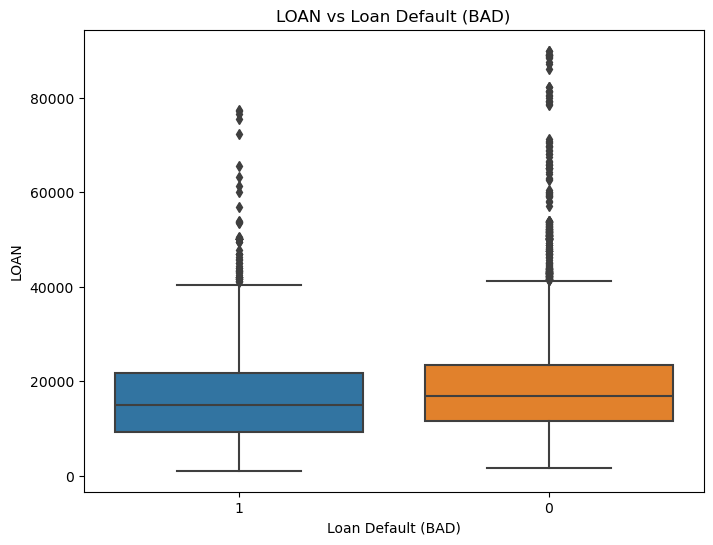

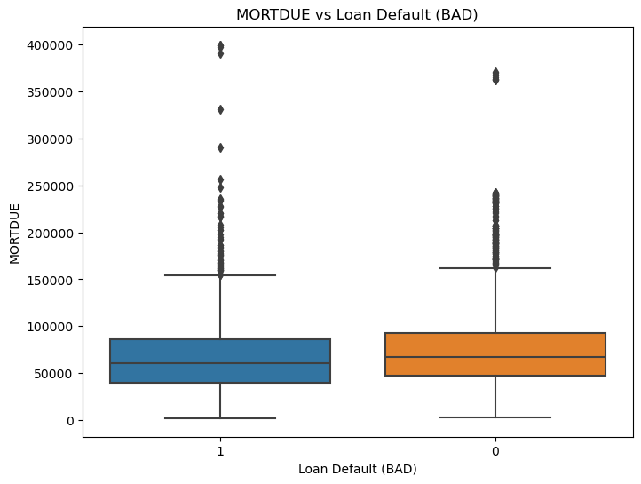

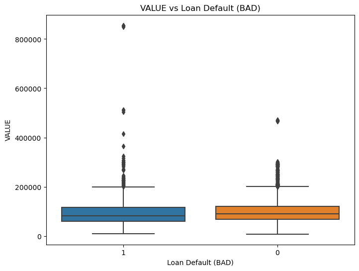

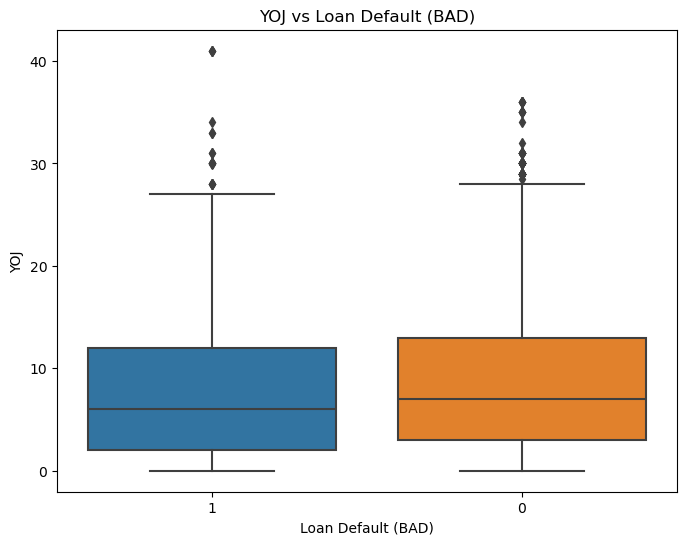

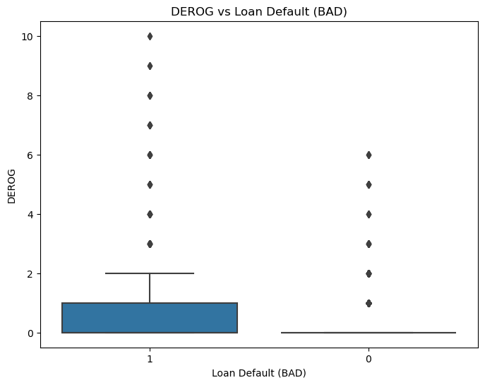

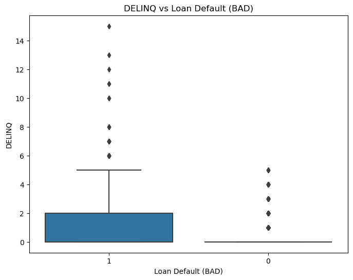

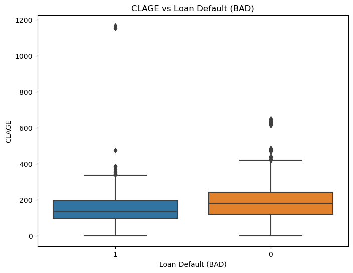

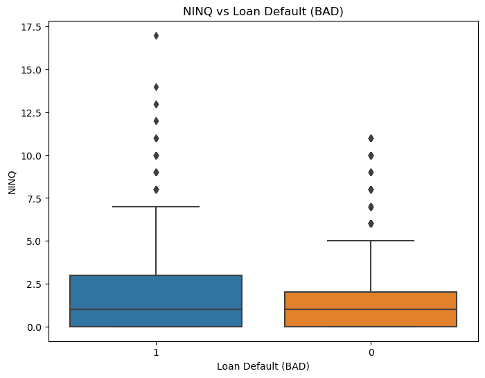

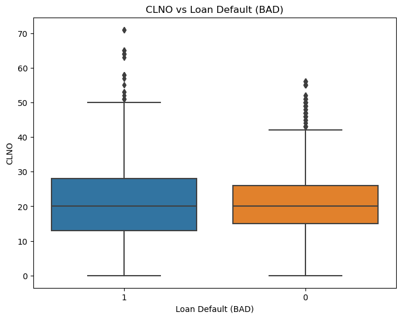

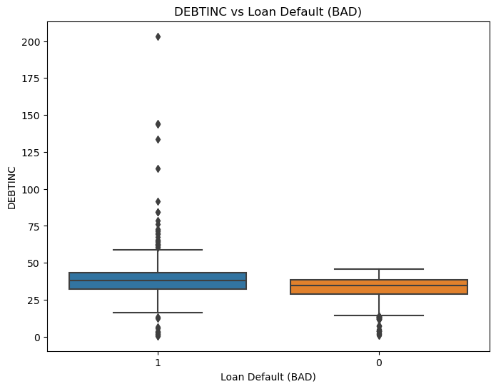

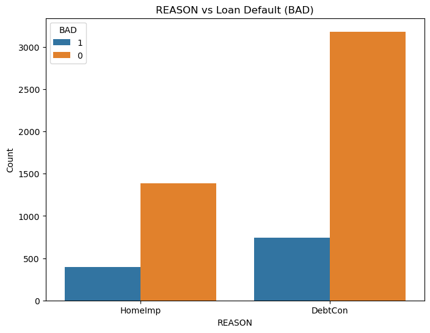

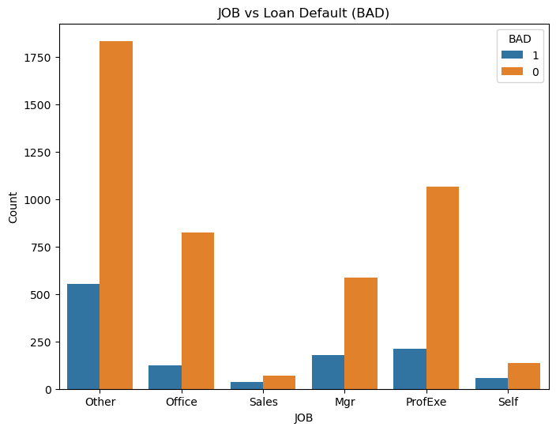

```
T-test for LOAN - p-value: 6.448273297751198e-09
  There is a significant difference in LOAN between default and non-default groups.

T-test for MORTDUE - p-value: 0.00037315277915502335
  There is a significant difference in MORTDUE between default and non-default groups.

T-test for VALUE - p-value: 0.021983705051567184
  There is a significant difference in VALUE between default and non-default groups.

T-test for YOJ - p-value: 8.66764069689319e-06
  There is a significant difference in YOJ between default and non-default groups.

T-test for DEROG - p-value: 1.645840590397121e-92
  There is a significant difference in DEROG between default and non-default groups.

T-test for DELINQ - p-value: 1.0560794844641107e-158
  There is a significant difference in DELINQ between default and non-default groups.

T-test for CLAGE - p-value: 3.959008762207894e-38
  There is a significant difference in CLAGE between default and non-default groups.

T-test for NINQ - p-value: 1.00164051118106e-38
  There is a significant difference in NINQ between default and non-default groups.

T-test for CLNO - p-value: 0.7528824048949208
  No significant difference in CLNO between default and non-default groups.

T-test for DEBTINC - p-value: 1.7814854021548954e-43
  There is a significant difference in DEBTINC between default and non-default groups.

Chi-Square Test for REASON - p-value: 0.004576181950707231
  There is a significant association between REASON and loan default.

Chi-Square Test for JOB - p-value: 3.306676232858524e-16
  There is a significant association between JOB and loan default.

T-test for LOAN - p-value: 6.448273297751198e-09, Cohen's d: -0.18694774119786609
T-test for MORTDUE - p-value: 0.00037315277915502335, Cohen's d: -0.1176937325813688
T-test for VALUE - p-value: 0.021983705051567184, Cohen's d: -0.06864653562306662
T-test for DEROG - p-value: 1.645840590397121e-92, Cohen's d: 0.5215697622206186
T-test for DELINQ - p-value: 1.0560794844641107e-158, Cohen's d: 0.689621012787376
T-test for CLAGE - p-value: 3.959008762207894e-38, Cohen's d: -0.43469380889719117
T-test for NINQ - p-value: 1.00164051118106e-38, Cohen's d: 0.39021059982365286
T-test for DEBTINC - p-value: 1.7814854021548954e-43, Cohen's d: 0.4562256841464301
Chi-Square Test for REASON - p-value: 0.004576181950707231, Cramér's V: 0.03753006571307943
Chi-Square Test for JOB - p-value: 3.306676232858524e-16, Cramér's V: 0.12009244336998369
```

```python
# I figure it would be most useful comparing values to their likelihood to default, so that's what this section primarily is:

# 1. Check Data Types
print("Data types of columns:")
print(df.dtypes)

# Ensure that the target column 'BAD' is treated as a categorical variable
df['BAD'] = df['BAD'].astype('object')  # Ensure 'BAD' is treated as a categorical column

# Explicitly convert BAD to string for plotting
df['BAD'] = df['BAD'].astype(str)  # Convert to string to avoid issue in legend handling

# Explicitly convert categorical columns to 'object' type if needed
categorical_features = df.select_dtypes(include=['object']).columns
for col in categorical_features:
    if df[col].dtype != 'object':  # If it's not already object type, convert it
        df[col] = df[col].astype('object')

# Now check data types again after conversion
print("\nData types after conversion:")
print(df.dtypes)

# 2. Compare Loan Default vs Numerical Features (e.g., LOAN, MORTDUE)
numerical_features = df.select_dtypes(include=['number']).columns

# Boxplots for numerical features vs loan default (BAD)
for col in numerical_features:
    if col != 'BAD':  # Exclude the target column
        plt.figure(figsize=(8, 6))
        sns.boxplot(x='BAD', y=col, data=df)
        plt.title(f'{col} vs Loan Default (BAD)')
        plt.xlabel('Loan Default (BAD)')
        plt.ylabel(col)
        plt.show()

# 3. Compare Loan Default vs Categorical Features (e.g., JOB, REASON)
# Bar plots for categorical features vs loan default (BAD)
for col in categorical_features:
    if col != 'BAD':  # Exclude the target column and ensure only valid categorical data
        if df[col].dtype == 'object':  # Only use categorical columns
            plt.figure(figsize=(8, 6))
            sns.countplot(x=col, hue='BAD', data=df)
            plt.title(f'{col} vs Loan Default (BAD)')
            plt.xlabel(col)
            plt.ylabel('Count')
            plt.show()

# 4. Statistical Comparison: T-test for Numerical Features
# For numerical features, compare default vs non-default groups (BAD = 1 vs BAD = 0)
for col in numerical_features:
    if col != 'BAD':  # Exclude the target column
        default_group = df[df['BAD'] == '1'][col]  # Check for string comparison
        non_default_group = df[df['BAD'] == '0'][col]  # Check for string comparison

        # Perform t-test for comparing means between defaulters and non-defaulters
        t_stat, p_val = ttest_ind(default_group.dropna(), non_default_group.dropna())
        print(f'T-test for {col} - p-value: {p_val}')
        if p_val < 0.05:
            print(f'  There is a significant difference in {col} between default and non-default groups.\n')
        else:
            print(f'  No significant difference in {col} between default and non-default groups.\n')

# 5. Statistical Comparison: Chi-Square Test for Categorical Features
# For categorical features, check if default is associated with the category
for col in categorical_features:
    if col != 'BAD':  # Exclude the target column
        if df[col].dtype == 'object':  # Ensure we are working with categorical data
            contingency_table = pd.crosstab(df[col], df['BAD'])

            # Perform Chi-Square test
            chi2_stat, p_val, dof, ex = chi2_contingency(contingency_table)
            print(f'Chi-Square Test for {col} - p-value: {p_val}')
            if p_val < 0.05:
                print(f'  There is a significant association between {col} and loan default.\n')
            else:
                print(f'  No significant association between {col} and loan default.\n')

# I kept getting a very persistent attribute error, so this code is a bit complicated just so I could convert BAD to an object.

# Also, I was surprised to see that every single column shows significant difference between loan defaulters and non-defaulters except CLNO, so I wanted
# to see the magnitude of their effect, to really zero in on the values that are most important to consider. I used Cohen's d and Cramér's V for this

# Function to calculate Cohen's d (for t-tests)
def cohens_d(group1, group2):
    mean1, mean2 = np.mean(group1), np.mean(group2)
    pooled_std = np.sqrt(((np.std(group1)**2) + (np.std(group2)**2)) / 2)
    d = (mean1 - mean2) / pooled_std
    return d

# Function to calculate Cramér's V (for chi-square tests)
def cramers_v(chi2_stat, n, k):
    return np.sqrt(chi2_stat / (n * (k - 1)))

# Columns for t-tests and chi-square tests (excluding CLNO)
numerical_features = ['LOAN', 'MORTDUE', 'VALUE', 'DEROG', 'DELINQ', 'CLAGE', 'NINQ', 'DEBTINC']
categorical_features = ['REASON', 'JOB']

# T-tests for numerical features
for col in numerical_features:
    if col != 'CLNO':  # Skip CLNO
        group_default = df[df['BAD'] == '1'][col]
        group_non_default = df[df['BAD'] == '0'][col]

        # Perform t-test for comparing means between defaulters and non-defaulters
        t_stat, p_val = ttest_ind(group_default.dropna(), group_non_default.dropna())
        d = cohens_d(group_default, group_non_default)
        print(f"T-test for {col} - p-value: {p_val}, Cohen's d: {d}")

# Chi-Square tests for categorical features
for col in categorical_features:
    if col != 'BAD':  # Exclude the target column
        contingency_table = pd.crosstab(df[col], df['BAD'])
        chi2_stat, p_val, dof, ex = chi2_contingency(contingency_table)

        # Calculate Cramér's V
        n = contingency_table.sum().sum()  # Total sample size
        k = min(contingency_table.shape)  # Number of categories (rows or columns)
        v = cramers_v(chi2_stat, n, k)

        print(f"Chi-Square Test for {col} - p-value: {p_val}, Cramér's V: {v}")

# This shows there is really only a significant difference in these values: DEROG, DELINQ, CLAGE, NINQ, DEBTINC, and JOB, with the largest being DELINQ,
# which makes sense.
```

### **Multivariate Analysis**

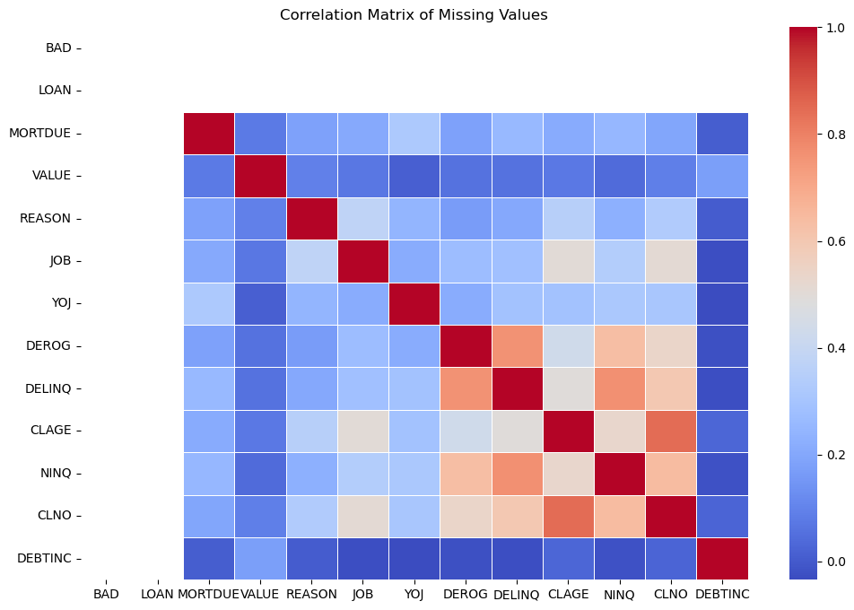

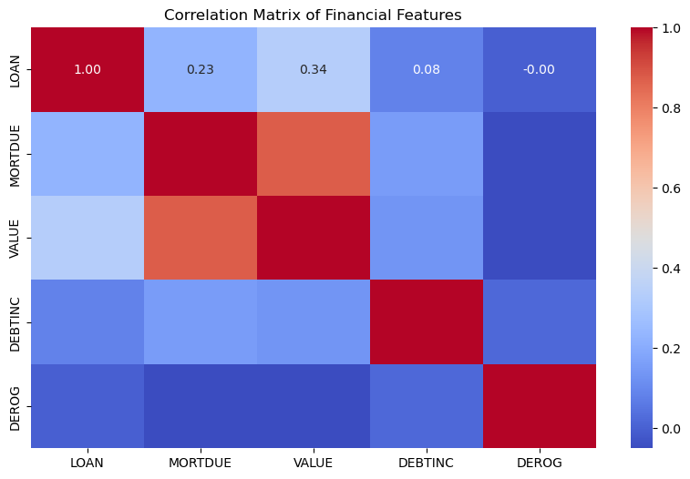

```python
# I decided to use a heatmap, one for missing values and one where all rows with missing values were dropped.

# Create a binary matrix where True = missing, False = not missing
missing_data = df.isnull()

# Compute the correlation matrix of missing values (True = missing, False = not missing)
corr_matrix_missing = missing_data.corr()

# Plot the correlation matrix for missing values
plt.figure(figsize=(12, 8))
sns.heatmap(corr_matrix_missing, annot=True, cmap='coolwarm', fmt='.2f', linewidths=0.5)
plt.title('Correlation Matrix of Missing Values')
plt.show()

# I tried everything I could to make the missing value heatmap line up with the x and y axes, but they refused.

# Compute the correlation matrix, take care of missing values by default
corr_matrix = df[['LOAN', 'MORTDUE', 'VALUE', 'DEBTINC', 'DEROG']].corr()

# Plot the correlation matrix as a heatmap
plt.figure(figsize=(10, 6))
sns.heatmap(corr_matrix, annot=True, cmap='coolwarm', fmt='.2f')
plt.title('Correlation Matrix of Financial Features')
plt.show()
```

## Treating Outliers

```python
# I'm not convinced this data needs outlier treatment. I want to see outliers first.

data = pd.read_csv("hmeq.csv")

# Define numeric columns in the new 'data' variable
numeric_columns = data.select_dtypes(include=[np.number]).columns

def identify_outliers_zscore(data, threshold=3):
    z_scores = np.abs(zscore(data))
    return z_scores > threshold

# Apply Z-Score method on numeric columns
outliers_zscore = data[numeric_columns].apply(identify_outliers_zscore)

# Step 2: Calculate IQR for outliers
Q1 = data[numeric_columns].quantile(0.25)
Q3 = data[numeric_columns].quantile(0.75)
IQR = Q3 - Q1

# Identify outliers (values beyond 1.5 * IQR)
outliers_iqr = (data[numeric_columns] < (Q1 - 1.5 * IQR)) | (data[numeric_columns] > (Q3 + 1.5 * IQR))

# Check for any significant differences between the mean and median
for col in numeric_columns:
    mean = data[col].mean()
    median = data[col].median()
    print(f"Mean and Median for {col}: Mean = {mean}, Median = {median}")
    if abs(mean - median) > 2 * data[col].std():
        print(f"  -> The data for {col} seems skewed and might need outlier treatment.")

# Print outliers detected by Z-Score and IQR methods
print("Outliers identified by Z-Score (Z > 3 or Z < -3):")
print(outliers_zscore.sum())  # Count of outliers in each column

print("Outliers identified by IQR method:")
print(outliers_iqr.sum())  # Count of outliers in each column

# I don't like the idea of treating outliers for the model. That seems like a mistake. I saw the largest values, and none seem like errors, but rather
# they show very high risk/very low risk indicators. I want to preserve this data, but to show that I am able to treat outliers, I will do another
# read command, separate from the data the model will look at. I chose loan and value, because they seem the most unreliable for prediction. If I did
# treat the outlier data before the model, these would be the values I would choose.

# Step 1: Treat outliers (using capping for the 'LOAN' and 'VALUE' columns)
def cap_outliers(data, column):
    Q1 = data[column].quantile(0.25)
    Q3 = data[column].quantile(0.75)
    IQR = Q3 - Q1
    data[column] = data[column].clip(lower=Q1 - 1.5 * IQR, upper=Q3 + 1.5 * IQR)
    return data

# Create 'data_outliers' by copying 'data' for treatment
data_outliers = data.copy()

# Apply capping to 'LOAN' and 'VALUE' columns in 'data_outliers'
data_outliers = cap_outliers(data_outliers, 'LOAN')
data_outliers = cap_outliers(data_outliers, 'VALUE')

# Step 2: Display Z-scores and IQR after treatment to show the effect on 'data_outliers'
z_scores_after = data_outliers[numeric_columns].apply(zscore)

# Identify outliers based on Z-score (Z > 3 or Z < -3)
outliers_zscore_after = (z_scores_after > 3) | (z_scores_after < -3)
outliers_zscore_count_after = outliers_zscore_after.sum()

# Calculate IQR after treatment
Q1_after = data_outliers[numeric_columns].quantile(0.25)
Q3_after = data_outliers[numeric_columns].quantile(0.75)
IQR_after = Q3_after - Q1_after

# Identify outliers based on IQR (values outside 1.5 * IQR)
outliers_iqr_after = (data_outliers[numeric_columns] < (Q1_after - 1.5 * IQR_after)) | (data_outliers[numeric_columns] > (Q3_after + 1.5 * IQR_after))
outliers_iqr_count_after = outliers_iqr_after.sum()

# Display the number of outliers after treatment
print("\nNumber of outliers after treatment (Z-Score method):")
print(outliers_zscore_count_after)

print("\nNumber of outliers after treatment (IQR method):")
print(outliers_iqr_count_after)
```

```
Mean and Median for BAD: Mean = 0.199496644295302, Median = 0.0
Mean and Median for LOAN: Mean = 18607.96979865772, Median = 16300.0
Mean and Median for MORTDUE: Mean = 73760.817199559, Median = 65019.0
Mean and Median for VALUE: Mean = 101776.04874145007, Median = 89235.5
Mean and Median for YOJ: Mean = 8.922268135904499, Median = 7.0
Mean and Median for DEROG: Mean = 0.2545696877380046, Median = 0.0
Mean and Median for DELINQ: Mean = 0.4494423791821561, Median = 0.0
Mean and Median for CLAGE: Mean = 179.76627518656605, Median = 173.46666667
Mean and Median for NINQ: Mean = 1.1860550458715597, Median = 1.0
Mean and Median for CLNO: Mean = 21.29609620076682, Median = 20.0
Mean and Median for DEBTINC: Mean = 33.779915348721126, Median = 34.818261819
Outliers identified by Z-Score (Z > 3 or Z < -3):
BAD         0
LOAN       95
MORTDUE     0
VALUE       0
YOJ         0
DEROG       0
DELINQ      0
CLAGE       0
NINQ        0
CLNO        0
DEBTINC     0
dtype: int64
Outliers identified by IQR method:
BAD        1189
LOAN        256
MORTDUE     234
VALUE       320
YOJ          91
DEROG       725
DELINQ     1201
CLAGE        47
NINQ        177
CLNO        219
DEBTINC      94
dtype: int64

Number of outliers after treatment (Z-Score method):
BAD        0
```

[output cut: 10 more lines]

```
dtype: int64

Number of outliers after treatment (IQR method):
BAD        1189
LOAN          0
MORTDUE     234
VALUE         0
YOJ          91
DEROG       725
DELINQ     1201
CLAGE        47
NINQ        177
CLNO        219
DEBTINC      94
dtype: int64
```

## Treating Missing Values

```python
# Just to be safe, I took a lot of precautions not to get rid of important missing values. For categorical data, I simply replaced them with 'Missing'.
# For numerical data, I separated the columns into 2 categories. The alarming missing values section (the columns debtinc and value, where there was
# a high chance that a missing value meant loan default, for whatever reason), and the regular missing values. For decision tree and random forest,
# I figured I could add a column regarding 'debtinc' and 'value' that would indicate the value in that other column is missing, and I'll tell the model
# to ignore the missing value, but focus on the column that says whether this value is missing. I know this is complicated, but those columns really
# indicated a very high risk if they were missing, so I didn't want to just put the mean in, and I couldn't drop so much data. I can't figure out the
# way to make this work with the logistical regression model, so I imputed with the mean in those columns, keeping the missingness indicator column
# (which is binary, 1 is missing, 0 is non missing)

# In hindsight, this caused a lot of problems and made the entire project very complicated. I don't regret it, I think the models I made performed well
# for what they would've otherwise, and I will continue to find creative ways to solve data problems.

# Create a copy of the data for Logistic Regression (we'll call it 'data_log_reg', to treat the missing values differently in the log regression model)
data_log_reg = data.copy()

# Categorical columns to handle missing values (REASON and JOB)
categorical_columns = ['REASON', 'JOB']

for col in categorical_columns:
    # Add missingness indicator column for categorical columns in both the original and the Log Reg copy
    data[f'{col}_missing'] = data[col].isnull().astype(int)
    data_log_reg[f'{col}_missing'] = data_log_reg[col].isnull().astype(int)

    # Replace missing values in categorical columns with 'Missing' in both the original and the Log Reg copy
    data[col].fillna('Missing', inplace=True)
    data_log_reg[col].fillna('Missing', inplace=True)

# Numerical columns to handle missing values (excluding VALUE and DEBTINC)
numerical_columns = ['MORTDUE', 'YOJ', 'DEROG', 'DELINQ', 'CLAGE', 'NINQ', 'CLNO']

for col in numerical_columns:
    # Add missingness indicator column for numerical columns in both the original and the Log Reg copy
    data[f'{col}_missing'] = data[col].isnull().astype(int)
    data_log_reg[f'{col}_missing'] = data_log_reg[col].isnull().astype(int)

    # Impute missing values in numerical columns with the median for the original data
    data[col].fillna(data[col].median(), inplace=True)

    # Impute missing values in numerical columns with the median for the Log Reg copy
    data_log_reg[col].fillna(data_log_reg[col].median(), inplace=True)

# For 'VALUE' and 'DEBTINC', handle missing values differently for Logistic Regression
for col in ['VALUE', 'DEBTINC']:
    # Add missingness indicator column for both the original data and Log Reg copy
    data[f'{col}_missing'] = data[col].isnull().astype(int)
    data_log_reg[f'{col}_missing'] = data_log_reg[col].isnull().astype(int)

    # For Logistic Regression, impute missing values with the mean
    data_log_reg[col].fillna(data_log_reg[col].mean(), inplace=True)

# Now, this is:
# - 'data_log_reg' (copy of data): Imputed missing values in 'VALUE' and 'DEBTINC' with the mean and added missingness indicator columns.
# - The original 'data': Imputed missing values for other columns (e.g., 'MORTDUE', 'YOJ') with the median and added missingness indicator columns.
# - 'VALUE' and 'DEBTINC' in the original data remain with missing values, with missingness indicator columns added.

# Check for missing values in the data_log_reg dataframe
missing_values = data_log_reg.isnull().sum()
missing_values0 = data.isnull().sum()

# Display the columns with missing values and their counts
print(missing_values)
print(missing_values0)

# Accidentally imputed the value and debtinc columns; apologies for messiness
# First, reset 'VALUE' and 'DEBTINC' columns to their original missing state

# Reapply the missingness
data['VALUE'] = df['VALUE']  # Make sure this column is restored to its original state (still missing)
data['DEBTINC'] = df['DEBTINC']  # Same for DEBTINC

# Recreate the missingness indicator columns for 'VALUE' and 'DEBTINC'
data['VALUE_missing'] = data['VALUE'].isnull().astype(int)
data['DEBTINC_missing'] = data['DEBTINC'].isnull().astype(int)

# Display the missingness indicator columns and count the number of 1s (missing values) for 'VALUE' and 'DEBTINC'
missing_indicator_values = data[['VALUE_missing', 'DEBTINC_missing']].sum()

# Output the result
print(missing_indicator_values)

# Check if 'VALUE' and 'DEBTINC' still have missing values after undoing the imputation
missing_values_after_undo = data[['VALUE', 'DEBTINC']].isnull().sum()
print(f"Missing values in 'VALUE' and 'DEBTINC' after undoing imputation:\n{missing_values_after_undo}")

# Step 1: Print the columns to check what is available in the dataset
print(data_log_reg.columns)
print(data.columns)
```

```
BAD                0
LOAN               0
MORTDUE            0
VALUE              0
REASON             0
JOB                0
YOJ                0
DEROG              0
DELINQ             0
CLAGE              0
NINQ               0
CLNO               0
DEBTINC            0
REASON_missing     0
JOB_missing        0
MORTDUE_missing    0
YOJ_missing        0
DEROG_missing      0
DELINQ_missing     0
CLAGE_missing      0
NINQ_missing       0
CLNO_missing       0
VALUE_missing      0
DEBTINC_missing    0
dtype: int64
BAD                   0
LOAN                  0
MORTDUE               0
VALUE               112
REASON                0
JOB                   0
YOJ                   0
DEROG                 0
DELINQ                0
CLAGE                 0
NINQ                  0
CLNO                  0
DEBTINC            1267
REASON_missing        0
JOB_missing           0
```

[output cut: 14 more lines]

```
VALUE       112
DEBTINC    1267
dtype: int64
Index(['BAD', 'LOAN', 'MORTDUE', 'VALUE', 'REASON', 'JOB', 'YOJ', 'DEROG',
       'DELINQ', 'CLAGE', 'NINQ', 'CLNO', 'DEBTINC', 'REASON_missing',
       'JOB_missing', 'MORTDUE_missing', 'YOJ_missing', 'DEROG_missing',
       'DELINQ_missing', 'CLAGE_missing', 'NINQ_missing', 'CLNO_missing',
       'VALUE_missing', 'DEBTINC_missing'],
      dtype='object')
Index(['BAD', 'LOAN', 'MORTDUE', 'VALUE', 'REASON', 'JOB', 'YOJ', 'DEROG',
       'DELINQ', 'CLAGE', 'NINQ', 'CLNO', 'DEBTINC', 'REASON_missing',
       'JOB_missing', 'MORTDUE_missing', 'YOJ_missing', 'DEROG_missing',
       'DELINQ_missing', 'CLAGE_missing', 'NINQ_missing', 'CLNO_missing',
       'VALUE_missing', 'DEBTINC_missing'],
      dtype='object')
```

## **Important Insights from EDA**

- What are the the most important observations and insights from the data based on the EDA performed?

Missing values in VALUE and DEBTINC were strongly linked to higher default rates, suggesting that missing financial data could indicate greater risk. This is important for handling missing data in the model.

Variables like DELINQ, DEROG, and NINQ, which track delinquencies and derogatory events, were the most influential in predicting defaults. This aligns with the idea that credit history and inquiries significantly affect default risk.

Lastly, the dataset is imbalanced, with more non-defaulting loans, which suggests the need for techniques like class weighting or oversampling to improve model predictions for the minority class.

## **Model Building - Approach**

- Data preparation
- Partition the data into train and test set
- Build the model
- Fit on the train data
- Tune the model
- Test the model on test set

### Logistic Regression

```python
data_log_reg['VALUE_missing'] = data['VALUE'].isnull().astype(int)
data_log_reg['DEBTINC_missing'] = data['DEBTINC'].isnull().astype(int)

# Step 1: Check the columns in your data before preprocessing
print(data_log_reg.columns)

# Accidentally added missing columns for all columns, used L1 too and wanted to drop the ones with a low threshold

# Step 2: Define the columns to drop
columns_to_drop = [
    'MORTDUE_missing', 'YOJ_missing', 'DEROG_missing', 'DELINQ_missing',
    'CLAGE_missing', 'NINQ_missing', 'CLNO_missing', 'REASON_missing'
]

# Filter columns to drop based on what actually exists in the dataset
existing_columns_to_drop = [col for col in columns_to_drop if col in data_log_reg.columns]

# Step 3: Drop the columns that are relevant (those that exist in the dataset)
data_log_reg = data_log_reg.drop(columns=existing_columns_to_drop)  # Only drop the existing ones

# Step 4: Define the target variable and features
X = data_log_reg.drop(columns=['BAD'])  # Assuming 'BAD' is the target variable for loan default
y = data_log_reg['BAD']

# Step 5: Partition the data into train and test sets (70% train, 30% test)
X_train, X_test, y_train, y_test = train_test_split(X, y, test_size=0.3, random_state=42)

# Step 6: Set up OneHotEncoding for categorical columns, including 'missing' categories
categorical_columns = ['REASON', 'JOB']  # List of categorical columns
numeric_columns = X.select_dtypes(include=['int64', 'float64']).columns.tolist()  # List of numeric columns

# Column transformer to handle categorical encoding and pass numeric columns unchanged
preprocessor = ColumnTransformer(
    transformers=[
        ('num', SimpleImputer(strategy='mean'), numeric_columns),  # Apply SimpleImputer for numerical columns
        ('cat', OneHotEncoder(drop='first', handle_unknown='ignore'), categorical_columns)  # OneHotEncoding for categorical columns
    ])

# Step 7: Build the Logistic Regression model with class weights and preprocessing pipeline
log_reg = Pipeline(steps=[
    ('preprocessor', preprocessor),  # Apply preprocessing (encoding and imputation)
    ('classifier', LogisticRegression(solver='liblinear', class_weight='balanced'))  # Logistic Regression with class weights
])

# Step 8: Fit the model on the train data
log_reg.fit(X_train, y_train)

# Step 9: Test the model on the test set
y_pred = log_reg.predict(X_test)

# Step 10: Evaluate the model's performance
accuracy = accuracy_score(y_test, y_pred)
print(f"Accuracy: {accuracy:.4f}")

print("\nClassification Report:")
print(classification_report(y_test, y_pred))

print("\nConfusion Matrix:")
print(confusion_matrix(y_test, y_pred))

# I did everything I could think of (some kept causing errors), and this model isn't very good. It's better than the results I got from the very basic
# version, but it's still biased towards loan repayments, and not very good at finding defaults. I also don't know why REASON and JOB don't show up
# properly in the index. They should have separate categories for each via One Hot Encoding, which isn't as simple as I thought initially.
```

```
Index(['BAD', 'LOAN', 'MORTDUE', 'VALUE', 'REASON', 'JOB', 'YOJ', 'DEROG',
       'DELINQ', 'CLAGE', 'NINQ', 'CLNO', 'DEBTINC', 'JOB_missing',
       'VALUE_missing', 'DEBTINC_missing'],
      dtype='object')
Accuracy: 0.7489

Classification Report:
              precision    recall  f1-score   support

           0       0.88      0.78      0.83      1389
           1       0.46      0.64      0.53       399

    accuracy                           0.75      1788
   macro avg       0.67      0.71      0.68      1788
weighted avg       0.79      0.75      0.76      1788


Confusion Matrix:
[[1084  305]
 [ 144  255]]
```

```python
# Step 1: Define the target variable and features
X = data.drop(columns=['BAD'])  # Dropping the target column 'BAD' from the data
y = data['BAD']

# Step 2: Create missingness indicator columns for REASON, JOB, VALUE, and DEBTINC
X['REASON_missing'] = X['REASON'].isnull().astype(int)
X['JOB_missing'] = X['JOB'].isnull().astype(int)
X['VALUE_missing'] = X['VALUE'].isnull().astype(int)
X['DEBTINC_missing'] = X['DEBTINC'].isnull().astype(int)

# Step 2: Define the columns to drop
columns_to_drop = [
    'MORTDUE_missing', 'YOJ_missing', 'DEROG_missing', 'DELINQ_missing',
    'CLAGE_missing', 'NINQ_missing', 'CLNO_missing'
]
# Filter columns to drop based on what actually exists in the dataset
existing_columns_to_drop = [col for col in columns_to_drop if col in data.columns]

# Step 3: Drop the columns that are relevant (those that exist in the dataset)
data = data.drop(columns=existing_columns_to_drop)  # Only drop the existing ones

# Step 3: Handle missing values by leaving them as they are for REASON, JOB, VALUE, and DEBTINC
# Apply one-hot encoding to REASON and JOB, including a "Missing" category
categorical_columns = ['REASON', 'JOB']
numeric_columns = X.select_dtypes(include=['int64', 'float64']).columns.tolist()

# Column transformer to handle categorical encoding and pass numeric columns unchanged
preprocessor = ColumnTransformer(
    transformers=[
        ('num', 'passthrough', numeric_columns),  # Leave numeric columns unchanged
        ('cat', OneHotEncoder(handle_unknown='ignore', drop='first'), categorical_columns)  # OneHotEncoding for categorical columns
    ])

# Step 4: Build the HistGradientBoostingClassifier model
model = Pipeline(steps=[
    ('preprocessor', preprocessor),  # Apply preprocessing (one-hot encoding for categorical columns)
    ('classifier', HistGradientBoostingClassifier(random_state=42))  # HistGradientBoostingClassifier to handle missing values
])

# Step 5: Partition the data into train and test sets (70% train, 30% test)
X_train, X_test, y_train, y_test = train_test_split(X, y, test_size=0.3, random_state=42)

# Step 6: Fit the model on the train data
model.fit(X_train, y_train)

# Step 7: Test the model on the test set
y_pred = model.predict(X_test)

# Step 8: Evaluate the model's performance
accuracy = accuracy_score(y_test, y_pred)
print(f"Accuracy: {accuracy:.4f}")

print("\nClassification Report:")
print(classification_report(y_test, y_pred))

print("\nConfusion Matrix:")
print(confusion_matrix(y_test, y_pred))

# This model seems good without hyperparameter tuning, but I used it in the Logistic Regression
```

```
Accuracy: 0.9189

Classification Report:
              precision    recall  f1-score   support

           0       0.92      0.98      0.95      1389
           1       0.89      0.72      0.80       399

    accuracy                           0.92      1788
   macro avg       0.91      0.85      0.87      1788
weighted avg       0.92      0.92      0.92      1788


Confusion Matrix:
[[1355   34]
 [ 111  288]]
```

- Hyperparameter tuning is tricky in the sense that **there is no direct way to calculate how a change in the hyperparameter value will reduce the loss of your model**, so we usually resort to experimentation. We'll use Grid search to perform hyperparameter tuning.
- **Grid search is a tuning technique that attempts to compute the optimum values of hyperparameters.**
- **It is an exhaustive search** that is performed on the specific parameter values of a model.
- The parameters of the estimator/model used to apply these methods are **optimized by cross-validated grid-search** over a parameter grid.

**Criterion {“gini”, “entropy”}**

The function to measure the quality of a split. Supported criteria are “gini” for the Gini impurity and “entropy” for the information gain.

**max_depth**

The maximum depth of the tree. If None, then nodes are expanded until all leaves are pure or until all leaves contain less than min_samples_split samples.

**min_samples_leaf**

The minimum number of samples is required to be at a leaf node. A split point at any depth will only be considered if it leaves at least min_samples_leaf training samples in each of the left and right branches. This may have the effect of smoothing the model, especially in regression.

You can learn about more Hyperpapameters on this link and try to tune them.

https://scikit-learn.org/stable/modules/generated/sklearn.tree.DecisionTreeClassifier.html

```python
from sklearn.model_selection import GridSearchCV
from sklearn.ensemble import HistGradientBoostingClassifier
from sklearn.pipeline import Pipeline
from sklearn.compose import ColumnTransformer
from sklearn.preprocessing import OneHotEncoder
from sklearn.model_selection import train_test_split
from sklearn.metrics import accuracy_score, classification_report, confusion_matrix

# Step 1: Define the target variable and features
X = data.drop(columns=['BAD'])  # Dropping the target column 'BAD' from the data
y = data['BAD']

# Step 2: Create missingness indicator columns for REASON, JOB, VALUE, and DEBTINC
X['REASON_missing'] = X['REASON'].isnull().astype(int)
X['JOB_missing'] = X['JOB'].isnull().astype(int)
X['VALUE_missing'] = X['VALUE'].isnull().astype(int)
X['DEBTINC_missing'] = X['DEBTINC'].isnull().astype(int)

# Step 2: Define the columns to drop
columns_to_drop = [
    'MORTDUE_missing', 'YOJ_missing', 'DEROG_missing', 'DELINQ_missing',
    'CLAGE_missing', 'NINQ_missing', 'CLNO_missing'
]
# Filter columns to drop based on what actually exists in the dataset
existing_columns_to_drop = [col for col in columns_to_drop if col in data.columns]

# Step 3: Drop the columns that are relevant (those that exist in the dataset)
data = data.drop(columns=existing_columns_to_drop)  # Only drop the existing ones

# Step 3: Handle missing values by leaving them as they are for REASON, JOB, VALUE, and DEBTINC
# Apply one-hot encoding to REASON and JOB, including a "Missing" category
categorical_columns = ['REASON', 'JOB']
numeric_columns = X.select_dtypes(include=['int64', 'float64']).columns.tolist()

# Column transformer to handle categorical encoding and pass numeric columns unchanged
preprocessor = ColumnTransformer(
    transformers=[
        ('num', 'passthrough', numeric_columns),  # Leave numeric columns unchanged
        ('cat', OneHotEncoder(handle_unknown='ignore', drop='first'), categorical_columns)  # OneHotEncoding for categorical columns
    ])

# Step 4: Build the HistGradientBoostingClassifier model
model = Pipeline(steps=[
    ('preprocessor', preprocessor),  # Apply preprocessing (one-hot encoding for categorical columns)
    ('classifier', HistGradientBoostingClassifier(random_state=42))  # HistGradientBoostingClassifier to handle missing values
])

# Step 5: Partition the data into train and test sets (70% train, 30% test)
X_train, X_test, y_train, y_test = train_test_split(X, y, test_size=0.3, random_state=42)

# Step 6: Define hyperparameter grid for tuning
param_grid = {
    'classifier__max_iter': [100, 200],  # Number of boosting iterations
    'classifier__max_depth': [None, 10, 20],  # Maximum depth of trees
    'classifier__learning_rate': [0.01, 0.1, 0.5],  # Learning rate for the gradient boosting model
    'classifier__min_samples_leaf': [10, 20],  # Minimum samples required to be at a leaf node
}

# Step 7: Set up GridSearchCV for hyperparameter tuning
grid_search = GridSearchCV(estimator=model, param_grid=param_grid, cv=5, n_jobs=-1, verbose=2)

# Step 8: Fit the model with hyperparameter tuning
grid_search.fit(X_train, y_train)

# Step 9: Get the best estimator from grid search
best_model = grid_search.best_estimator_

# Step 10: Test the model on the test set
y_pred = best_model.predict(X_test)

# Step 11: Evaluate the model's performance
accuracy = accuracy_score(y_test, y_pred)
print(f"Accuracy: {accuracy:.4f}")

print("\nClassification Report:")
print(classification_report(y_test, y_pred))

print("\nConfusion Matrix:")
print(confusion_matrix(y_test, y_pred))

# Optionally, if you want to check the best hyperparameters:
print("\nBest Hyperparameters from Grid Search:")
print(grid_search.best_params_)
```

```
Fitting 5 folds for each of 36 candidates, totalling 180 fits
Accuracy: 0.9284

Classification Report:
              precision    recall  f1-score   support

           0       0.94      0.98      0.95      1389
           1       0.90      0.76      0.83       399

    accuracy                           0.93      1788
   macro avg       0.92      0.87      0.89      1788
weighted avg       0.93      0.93      0.93      1788


Confusion Matrix:
[[1355   34]
 [  94  305]]

Best Hyperparameters from Grid Search:
{'classifier__learning_rate': 0.5, 'classifier__max_depth': None, 'classifier__max_iter': 200, 'classifier__min_samples_leaf': 20}
```

### **Building a Random Forest Classifier**

**Random Forest is a bagging algorithm where the base models are Decision Trees.** Samples are taken from the training data and on each sample a decision tree makes a prediction.

**The results from all the decision trees are combined together and the final prediction is made using voting or averaging.**

```python
# Step 1: Define the target variable and features
X = data.drop(columns=['BAD'])  # Assuming 'BAD' is the target variable for loan default
y = data['BAD']

# Step 2: Partition the data into train and test sets (70% train, 30% test)
X_train, X_test, y_train, y_test = train_test_split(X, y, test_size=0.3, random_state=42)

# Step 3: Set up OneHotEncoding for categorical columns with missing values treated as 'Missing'
categorical_columns = ['REASON', 'JOB']  # List of categorical columns
numeric_columns = X.select_dtypes(include=['int64', 'float64']).columns.tolist()  # List of numeric columns

# Column transformer to handle categorical encoding and pass numeric columns unchanged
preprocessor = ColumnTransformer(
    transformers=[
        ('num', SimpleImputer(strategy='mean'), numeric_columns),  # Apply SimpleImputer for numerical columns
        ('cat', OneHotEncoder(drop='first'), categorical_columns)  # Apply OneHotEncoder for categorical columns
    ])

# Step 4: Build the Random Forest model with preprocessing pipeline
random_forest = Pipeline(steps=[
    ('preprocessor', preprocessor),  # Apply preprocessing (encoding and imputation)
    ('classifier', RandomForestClassifier(n_estimators=100, random_state=42))  # Random Forest model
])

# Step 5: Fit the model on the train data
random_forest.fit(X_train, y_train)

# Step 6: Test the model on the test set
y_pred = random_forest.predict(X_test)

# Step 7: Evaluate the model
accuracy = accuracy_score(y_test, y_pred)
print(f"Accuracy: {accuracy:.4f}")

# Additional Evaluation Metrics
print("\nClassification Report:")
print(classification_report(y_test, y_pred))

print("\nConfusion Matrix:")
print(confusion_matrix(y_test, y_pred))
```

```
Accuracy: 0.9060

Classification Report:
              precision    recall  f1-score   support

           0       0.91      0.98      0.94      1389
           1       0.90      0.65      0.76       399

    accuracy                           0.91      1788
   macro avg       0.90      0.81      0.85      1788
weighted avg       0.91      0.91      0.90      1788


Confusion Matrix:
[[1361   28]
 [ 140  259]]
```

### **Random Forest Classifier Hyperparameter Tuning**

```python
# Step 1: Define the target variable and features
X = data.drop(columns=['BAD'])  # Assuming 'BAD' is the target variable for loan default
y = data['BAD']

# Step 2: Partition the data into train and test sets (70% train, 30% test)
X_train, X_test, y_train, y_test = train_test_split(X, y, test_size=0.3, random_state=42)

# Step 3: Define the preprocessor pipeline
# Impute missing numerical values (e.g., VALUE, DEBTINC) and OneHotEncode categorical columns (e.g., REASON, JOB)
numerical_columns = X.select_dtypes(include=['int64', 'float64']).columns.tolist()
categorical_columns = ['REASON', 'JOB']  # List of categorical columns that need encoding

# ColumnTransformer to handle numerical imputation and categorical encoding
preprocessor = ColumnTransformer(
    transformers=[
        ('num', SimpleImputer(strategy='mean'), numerical_columns),  # Impute numerical columns with mean
        ('cat', Pipeline(steps=[
            ('imputer', SimpleImputer(strategy='constant', fill_value='Missing')),  # Impute missing categorical data
            ('encoder', OneHotEncoder(drop='first'))  # OneHotEncode categorical columns
        ]), categorical_columns)  # Apply to REASON and JOB columns
    ])

# Step 4: Create the Random Forest model pipeline with preprocessing
random_forest = RandomForestClassifier(random_state=42)

pipeline = Pipeline(steps=[
    ('preprocessor', preprocessor),  # Apply preprocessing (imputation and encoding)
    ('classifier', random_forest)  # Random Forest classifier
])

# Step 5: Hyperparameter tuning using GridSearchCV
param_grid = {
    'classifier__n_estimators': [50, 100, 200],  # Number of trees in the forest
    'classifier__max_depth': [None, 10, 20, 30],  # Maximum depth of the tree
    'classifier__min_samples_split': [2, 5, 10],  # Minimum samples required to split a node
    'classifier__min_samples_leaf': [1, 2, 4],    # Minimum samples required at a leaf node
    'classifier__bootstrap': [True, False]        # Whether bootstrap samples are used when building trees
}

grid_search_rf = GridSearchCV(estimator=pipeline, param_grid=param_grid, cv=5, n_jobs=-1, verbose=2)
grid_search_rf.fit(X_train, y_train)

# Step 6: Best Hyperparameters from Grid Search
best_rf = grid_search_rf.best_estimator_
print("\nBest Hyperparameters from Grid Search:")
print(grid_search_rf.best_params_)

# Step 7: Test the model on the test set
y_pred_rf = best_rf.predict(X_test)

# Step 8: Evaluate the model
accuracy_rf = accuracy_score(y_test, y_pred_rf)
print(f"Accuracy: {accuracy_rf:.4f}")

# Additional Evaluation Metrics
print("\nClassification Report:")
print(classification_report(y_test, y_pred_rf))

print("\nConfusion Matrix:")
print(confusion_matrix(y_test, y_pred_rf))

# Shockingly, this took several minutes to print everything.
```

```
Fitting 5 folds for each of 216 candidates, totalling 1080 fits

Best Hyperparameters from Grid Search:
{'classifier__bootstrap': False, 'classifier__max_depth': 20, 'classifier__min_samples_leaf': 1, 'classifier__min_samples_split': 5, 'classifier__n_estimators': 100}
Accuracy: 0.9111

Classification Report:
              precision    recall  f1-score   support

           0       0.91      0.98      0.94      1389
           1       0.89      0.68      0.77       399

    accuracy                           0.91      1788
   macro avg       0.90      0.83      0.86      1788
weighted avg       0.91      0.91      0.91      1788


Confusion Matrix:
[[1357   32]
 [ 127  272]]
```

**1. Comparison of various techniques and their relative performance based on chosen Metric (Measure of success):**

- How do different techniques perform? Which one is performing relatively better? Is there scope to improve the performance further?

I think there's always a lot more someone can do--changing weights, using L1/k-folds for cross-validation, feature scaling during preprocessing. Even combining models might be useful in some contexts.

**2. Refined insights:**

- What are the most meaningful insights relevant to the problem?

**3. Proposal for the final solution design:**

- What model do you propose to be adopted? Why is this the best solution to adopt?